# Preparation

## 实验介绍

### 0. What I Do

1. 通过自定义函数`mscatter()`实现了基于`matplotlib.pyplot.scatter()`画出各个类别的不同**形状**
2. 学习`Seaborn`函数库，通过`seaborn.scatterplot()`的`hue`属性区分不同类别

> 事实上，只需要**颜色、大小、形状**一种特征不同即可区别类别

> 由于`scatter.legend_element()`中的`prop`的属性值只有'sizes'和'colors'

> 因此，为了给不同的类别标上标签，最好使用颜色或大小不同的方案

**结论**：

- 使用`Seaborn`函数库比`Matplotlib`更方便，且更美观
- 不要重复造轮子……

### 1.实验内容

本实验包括:

- 熟悉课程平台Jupyter实验环境
- 使用Matplotlib创建散点图

### 2.实验目标

通过实验熟悉课程平台环境，掌握Jupyter的基础操作

### 3.实验环境

> 备注：这是本地实验环境
- python 3.8.4
- numpy 1.22.4
- matplotlib 3.5.2

```python
# !pip list
```

```python
# !python --version
```

### 实验准备

点击屏幕右上方的下载实验数据模块，选择下载kNN_Dating.tgz到指定目录下，然后再依次选择点击上方的File->Open->Upload,上传刚才下载的数据集压缩包，再使用如下命令解压：

```python
# 已经解压过，不必再运行
# !tar -zxvf /home/jovyan/work/kNN_Dating.tgz
```

```python
import numpy as np
import matplotlib.lines as mlines
import matplotlib.pyplot as plt
import pandas as pd              # 导入pandas库，读取数据
```

## 实验步骤：【绘制散点图】- 概述

### 数据介绍

海伦收集约会数据已经有了一段时间，她把这些数据存放在文本文件datingTestSet.txt中，每个样本数据占据一行，总共有1000行。

海伦收集的样本数据主要包含以下3种特征：

- 每年获得的飞行常客里程数 (Number of frequent flyer miles earned per year)
- 玩视频游戏所消耗时间百分比 (Percentage of time spent playing video games)
- 每周消费的冰淇淋公升数 (Liters of ice cream consumed per week)

数据标签包含以下3类：

- 不喜欢的人 (didntLike)
- 魅力一般的人 (smallDoses)
- 极具魅力的人 (largeDoses)

### 数据示例

[figure not shown]

## 实验步骤：【绘制散点图】- 数据读取与处理

将数据分类两部分，即特征矩阵和对应的分类标签向量。定义名为file2matrix的函数，以此来处理输入格式问题。编写代码如下：

```python
def file2matrix(filename):
    """
    函数说明：加载数据集
    parameters:
        fileName - 文件名
    return:
        featureMat - 特征矩阵
        classLabelVector - 类别标签向量(didntLike - 0, smallDoses - 1, largeDoses - 2)
    """
    data = pd.read_table(filename, header=None)    # 用Pandas读入数据，格式为DataFrame
    data.iloc[:,3]=data.iloc[:,3].map({'didntLike': 0, 'smallDoses': 1, 'largeDoses': 2})
    featureMat = data.iloc[:,:3]
    classLabelVector = data.iloc[:,3]
    # featureMat = featureMat.values.tolist()      # DataFrame转Matrix
    # classLabelVector = classLabelVector.values.tolist()

    featureMat = np.array(featureMat)      # DataFrame转Ndarray(Numpy)
    classLabelVector = np.array(classLabelVector)

    return featureMat, classLabelVector
```

## 实验步骤：【绘制散点图】- 分析数据数据可视化

### 预期可视化结果

[figure not shown]

```python
def showdatas1(datingDataMat, datingLabels):
    """
    函数说明：绘制散点图，通过np.argwher()来找到标签与特征矩阵的映射关系
    parameters:
        datingDataMat - 特征矩阵
        datingLabels - 类别标签向量(didntLike - 0, smallDoses - 1, largeDoses - 2)
    """
    didntLike = np.array(datingDataMat)[np.argwhere(np.array(datingLabels) == 0)]
    didntLike.resize(didntLike.shape[0], didntLike.shape[2])
    smallDoses = np.array(datingDataMat)[np.argwhere(np.array(datingLabels) == 1)]
    smallDoses.resize(smallDoses.shape[0], smallDoses.shape[2])
    largeDoses = np.array(datingDataMat)[np.argwhere(np.array(datingLabels) == 2)]
    largeDoses.resize(largeDoses.shape[0], largeDoses.shape[2])

    plt.figure(figsize=[18,6])
    plt.scatter(didntLike[:,0],didntLike[:,1],label='didntLike')
    plt.scatter(smallDoses[:,0],smallDoses[:,1],label='smallDoses')
    plt.scatter(largeDoses[:,0],largeDoses[:,1],label='largeDoses')
    plt.legend()
    plt.xlabel('Number of frequent flyer miles eamed per year')
    plt.ylabel('Percentage of time spent playing video games')

    plt.figure(figsize=[18,6])
    plt.scatter(didntLike[:,0],didntLike[:,2],label='didntLike')
    plt.scatter(smallDoses[:,0],smallDoses[:,2],label='smallDoses')
    plt.scatter(largeDoses[:,0],largeDoses[:,2],label='largeDoses')
    plt.xlabel('Number of frequent flyer miles eamed per year')
    plt.ylabel('Liters of ice cream consumed per week')
    plt.legend()

    plt.figure(figsize=[18,6])
    plt.scatter(didntLike[:,1],didntLike[:,2],label='didntLike')
    plt.scatter(smallDoses[:,1],smallDoses[:,2],label='smallDoses')
    plt.scatter(largeDoses[:,1],largeDoses[:,2],label='largeDoses')
    plt.xlabel('Percentage of time spent playing video games')
    plt.ylabel('Liters of ice cream consumed per week')
    plt.legend()
    plt.show()
```

```python
def mscatter(x, y, ax=None, m=None, **kw):
    """
    函数说明：自定义绘制散点图，可实现不同类别的形状不同
    parameters:
        x, y - 作为一组坐标
        ax - 表示需要绘制在指定的axes中
        m - 表示各类别对应的形状
        **kw - 可以传入大小、颜色等属性
    return:
        sc - `~matplotlib.collections.PathCollection`
    """
    import matplotlib.markers as mmarkers
    if not ax: ax = plt.gca()
    sc = ax.scatter(x, y, **kw)
    if (m is not None) and (len(m) == len(x)):
        paths = []
        for marker in m:
            if isinstance(marker, mmarkers.MarkerStyle):
                marker_obj = marker
            else:
                marker_obj = mmarkers.MarkerStyle(marker)
            path = marker_obj.get_path().transformed(
                marker_obj.get_transform())
            paths.append(path)
        sc.set_paths(paths)
    return sc
```

```python
def showdatas2(datingDataMat, datingLabels):
    """
    函数说明：绘制散点图，直接利用plt.scatter()的高级参数，即传入size和color序列，完成映射
    parameters:
        datingDataMat - 特征矩阵
        datingLabels - 类别标签向量(didntLike - 0, smallDoses - 1, largeDoses - 2)
    """
    map_marker = {0: 'o', 1: 's', 2: '*'}
    markers = list(map(lambda x: map_marker[x], datingLabels))

    fig = plt.figure(figsize=[18,18])

    ax1 = fig.add_subplot(311)
    scatter1 = ax1.scatter(datingDataMat[:, 0], datingDataMat[:, 1], s = 30.0 * (np.array(datingLabels) + 1), c = 15.0 * np.array(datingLabels))
    a, b = scatter1.legend_elements()
    b = ['$\\mathdefault {didntLike}$', '$\\mathdefault{smallDoses}$', '$\\mathdefault{largeDoses}$']
    ax1.legend(a, b)
    ax1.set(xlabel='Number of frequent flyer miles eamed per year', ylabel='Percentage of time spent playing video games')

    ax2 = fig.add_subplot(312)
    mscatter(datingDataMat[:, 0], datingDataMat[:, 2], s = 30.0 * (np.array(datingLabels) + 1), c = 15.0 * np.array(datingLabels), ax = ax2, m = np.array(markers))
    ax2.legend(a, b)
    ax2.set(xlabel='Number of frequent flyer miles eamed per year', ylabel='Liters of ice cream consumed per week')


    ax3 = fig.add_subplot(313)
    ax3.scatter(datingDataMat[:, 1], datingDataMat[:, 2], s = 30.0 * (np.array(datingLabels) + 1), c = 15.0 * np.array(datingLabels), alpha = 0.6)
    ax3.legend(a, b)
    ax3.set(xlabel='Percentage of time spent playing video games', ylabel='Liters of ice cream consumed per week')


    plt.show()
```

```python
def showdatas3(datingDataMat, datingLabels):
    """
    函数说明：绘制散点图，基于Seaborn实现
    parameters:
        datingDataMat - 特征矩阵
        datingLabels - 类别标签向量(didntLike - 0, smallDoses - 1, largeDoses - 2)
    """
    import seaborn as sns
    data = pd.DataFrame(datingDataMat)
    map_label = {0: 'didntLike', 1: 'smallDoses', 2: 'largeDoses'}
    datingLabels = list(map(lambda x: map_label[x], datingLabels))

    fig = plt.figure(figsize=[18,18])

    ax1 = fig.add_subplot(311)
    sns.scatterplot(x=0,y=1,data=data,hue=datingLabels, ax=ax1)
    ax1.set(xlabel='Number of frequent flyer miles eamed per year', ylabel='Percentage of time spent playing video games')


    ax2 = fig.add_subplot(312)
    sns.scatterplot(x=0,y=2,data=data,hue=datingLabels, ax=ax2)
    ax2.set(xlabel='Number of frequent flyer miles eamed per year', ylabel='Liters of ice cream consumed per week')


    ax3 = fig.add_subplot(313)
    sns.scatterplot(x=1,y=2,data=data,hue=datingLabels, ax=ax3)
    ax3.set(xlabel='Percentage of time spent playing video games', ylabel='Liters of ice cream consumed per week')

    plt.show()
```

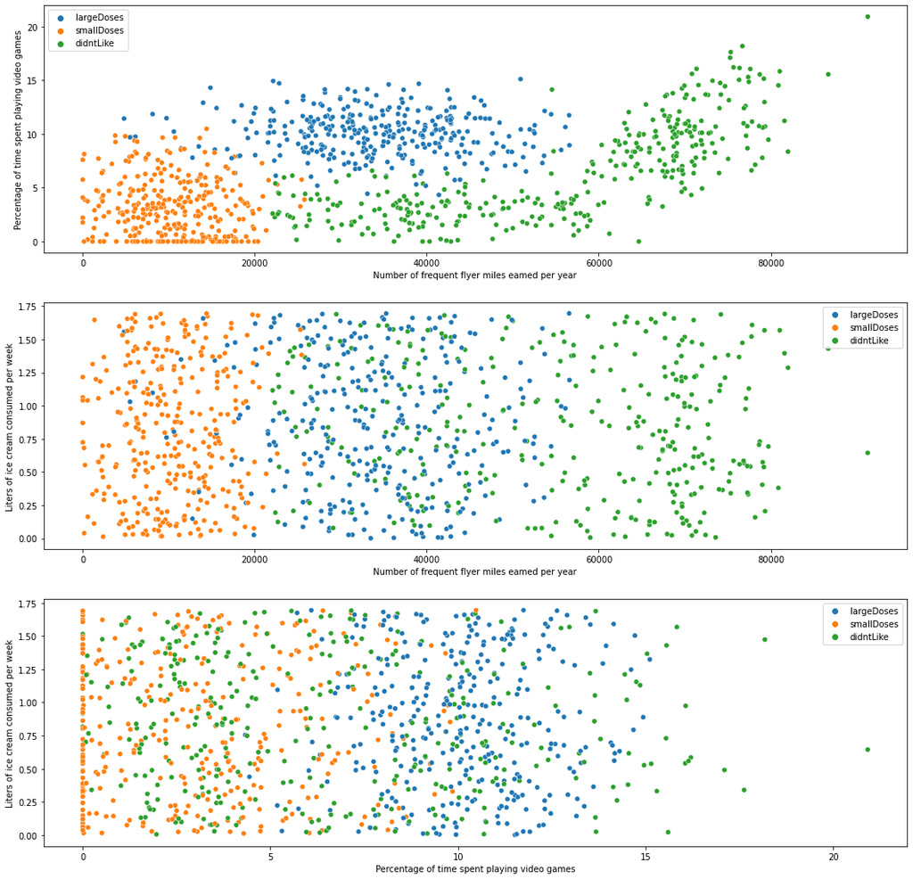

```python
if __name__ == '__main__':
    filename = "kNN_Dating/datingTestSet.txt"
    datingDataMat, datingLabels = file2matrix(filename)
    # showdatas1(datingDataMat, datingLabels)
    # showdatas2(datingDataMat, datingLabels)
    showdatas3(datingDataMat, datingLabels)
```